# Diamond Price Estimation

Yunus Emre TOPRAK

10 09 2020

# 1 Diamonds

Diamond is a solid form of the element carbon with its atoms arranged in a crystal structure called diamond cubic. Diamonds are very rare items,at the same time they are bright and beautiful. That’s why diamonds are precious gemstones. According to [this article](https://www.diamondrocks.co.uk/magazine/why-are-diamonds-so-valuable/) they are more expensive when the stone is rare.

According to this [site](https://www.wixonjewelers.com/education-type/diamond-shapes/), the price of a diamond is related with it’s shape and 4Cs..

- **[Cut](https://www.bluenile.com/education/diamonds/cut)**: A diamond’s cut refers to how well-proportioned the dimensions of a diamond are, and how these surfaces, or facets, are positioned to create sparkle and brilliance.
  - A well cut diamond is luminous and reflects white and colored light back to your eyes.
  - Cut types are explained below:
    - *Ideal*: This rare cut represents roughly the top 3% of diamond cut quality. It reflects most of the light that enters the diamond.
    - *Very Good*: This cut represents roughly the top 15% of diamond cut quality. It reflects nearly as much light as the ideal cut, but for a lower price.
    - *Good*: his cut represents roughly the top 25% of diamond cut quality. It reflects most of the light that enters, but not as much as a Very Good cut grade.
    - *Astor by Blue Nile™*: These diamonds are crafted to gather and reflect the most light possible. Cut from the finest raw material (rough stones with as few impurities or inclusions as possible), they meet rigorous quality requirements and exhibit outstanding brilliance, fire, and scintillation. In addition to being graded by the GIA, all Astor by Blue Nile™ diamonds are certified by GemEx®

In this [link](https://www.bluenile.com/education/diamonds/shape/price-comparison), you can find some shapes of a diamond and their prices.

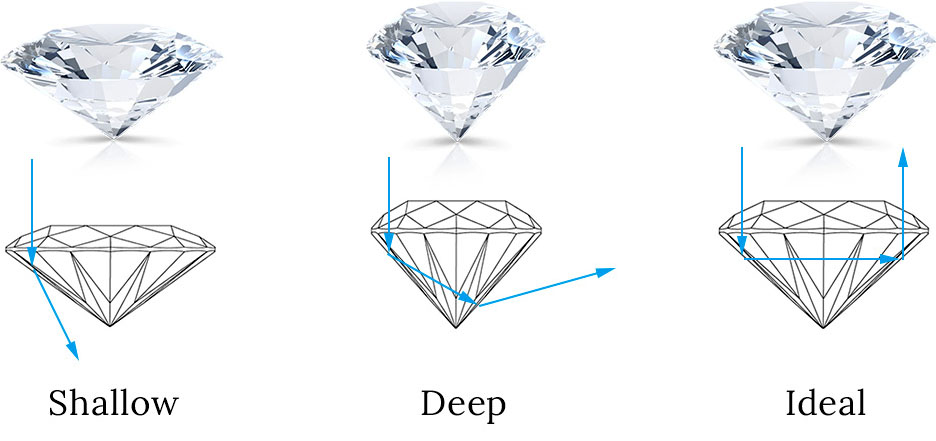

Figure 1: Looks of Cuts

- **[Color](https://www.bluenile.com/education/diamonds/color)**: A diamond’s color refers to how clear or yellow it is. Diamonds are found in almost any naturally occurring color, including gray, white, yellow, green, brown, and pink.
  - Part of diamond valuation is determined by the absence of color.
  - Diamond prices decline or increase in alphabetical order. For example, a diamond with a G color grade is less expensive than a diamond with a D color grade.
  - Diamond colors are graded from D to Z, with most diamonds used in jewelry falling somewhere into the D to M range. It means that the colors after M are not very popular.

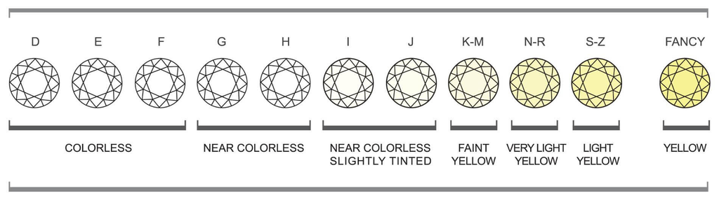

Figure 2. Color Scales of Diamonds

- **[Clarity](https://www.bluenile.com/education/diamonds/clarity)**: Diamond clarity is the assessment of small imperfections on the surface and within the stone.
  - The term “eye clean” means that the diamond’s inclusions are too small to see without magnification.
  - Diamond shape and size affect clarity. While clarity is less important than a diamond’s cut or color, if you are buying a diamond over one carat or considering certain fancy-shaped diamonds (like an emerald or Asscher cut where flaws are more visible), you may want to spend more for a higher clarity grade
  - Five factors play a significant role in how the clarity grades are determined. These five roles in diamond grading include *size*, *nature*, *number*, *location*, and the *relief* of the inclusions.

[figure not shown]

Figure 3. Classification of Diamonds by Clarity

- **[Carat](https://www.bluenile.com/education/diamonds/carat-weight)**: The term carat is often misunderstood. It refers to a diamond’s weight, not its size. Another misperception is that a larger carat weight is always better than a smaller carat weight.
  - One diamond carat would be equal to 200 mg, or .2 grams, of a diamond.
  - Diamonds with higher carat weights are cut from larger rough crystals that are harder to source than small crystals
  - the relationship between carat weight and price depends on the rarity or availability of a rough crystal
  - 4 Things To Know About Carat: “Buy shy” to save money, Splurge on cut, Fancy shapes cost less per carat, Keep ring size in mind

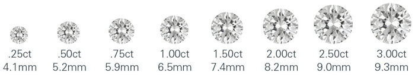

# 2 Data and Required Packages

## 2.1 Data Information

In this [assignment](https://mef-bda503.github.io/archive/fall17/files/assignment_diamonds_data.html), objectives can be listed as following:

1. To provide useful exploratory analysis
2. To generate a model for prediction of the diamond price

To fulfill these objectives, (i) data is analyzed and prepared for the analysis, (ii) the meaningful EDA is presented by using some useful packages such as `ggplot2`, `rattle`, `knitr` etc.

```r
library(tidyverse)
library(data.table)
library(knitr)
library(kableExtra)
library(rpart.plot)
library(RColorBrewer)
library(caret)
library(e1071)
library(rpart)
library(rpart.plot)
library(rattle)
library(corrplot)
```

The dataset in this analysis is obtained from the `ggplot2` packages. This data set contains 53940 rows and 10 variables. There is no shape column in this dataset. By using this `glimpse()` function, we obtain these variables.

```r
#variables of the dataset
diamonds %>%
  glimpse()
```

```
## Rows: 53,940
## Columns: 10
## $ carat   <dbl> 0.23, 0.21, 0.23, 0.29, 0.31, 0.24, 0.24, 0.26, 0.22, 0.23,...
## $ cut     <ord> Ideal, Premium, Good, Premium, Good, Very Good, Very Good, ...
## $ color   <ord> E, E, E, I, J, J, I, H, E, H, J, J, F, J, E, E, I, J, J, J,...
## $ clarity <ord> SI2, SI1, VS1, VS2, SI2, VVS2, VVS1, SI1, VS2, VS1, SI1, VS...
## $ depth   <dbl> 61.5, 59.8, 56.9, 62.4, 63.3, 62.8, 62.3, 61.9, 65.1, 59.4,...
## $ table   <dbl> 55, 61, 65, 58, 58, 57, 57, 55, 61, 61, 55, 56, 61, 54, 62,...
## $ price   <int> 326, 326, 327, 334, 335, 336, 336, 337, 337, 338, 339, 340,...
## $ x       <dbl> 3.95, 3.89, 4.05, 4.20, 4.34, 3.94, 3.95, 4.07, 3.87, 4.00,...
## $ y       <dbl> 3.98, 3.84, 4.07, 4.23, 4.35, 3.96, 3.98, 4.11, 3.78, 4.05,...
## $ z       <dbl> 2.43, 2.31, 2.31, 2.63, 2.75, 2.48, 2.47, 2.53, 2.49, 2.39,...
```

## 2.2 Data Preprocessing

In this stage, the data is analyzed or pre-processed before the detailed analyses. First step is to check null values.

```r
#to control NA values in the dataset
sum(any(is.na(diamonds)))
```

```
## [1] 0
```

There is 0 NA value. This means that there is no missing value in any row or column. Second step is to check for duplicated rows.

```r
sum(as.numeric(duplicated(diamonds)))
```

```
## [1] 146
```

By using above function we can obtain number of exactly the same rows in this dataset. There are 146 duplicated lines. Before the analysis, we have to extract these data from the data frame. To solve this problem, i used `unique()` function.

```r
#taking only unique rows form the data set
diamonds <- unique(diamonds)
```

After this step, we have 53794 rows and 10 columns. Third step could check the types of these variables with `str()` function

```r
str(diamonds)
```

```
## tibble [53,794 x 10] (S3: tbl_df/tbl/data.frame)
##  $ carat  : num [1:53794] 0.23 0.21 0.23 0.29 0.31 0.24 0.24 0.26 0.22 0.23 ...
##  $ cut    : Ord.factor w/ 5 levels "Fair"<"Good"<..: 5 4 2 4 2 3 3 3 1 3 ...
##  $ color  : Ord.factor w/ 7 levels "D"<"E"<"F"<"G"<..: 2 2 2 6 7 7 6 5 2 5 ...
##  $ clarity: Ord.factor w/ 8 levels "I1"<"SI2"<"SI1"<..: 2 3 5 4 2 6 7 3 4 5 ...
##  $ depth  : num [1:53794] 61.5 59.8 56.9 62.4 63.3 62.8 62.3 61.9 65.1 59.4 ...
##  $ table  : num [1:53794] 55 61 65 58 58 57 57 55 61 61 ...
##  $ price  : int [1:53794] 326 326 327 334 335 336 336 337 337 338 ...
##  $ x      : num [1:53794] 3.95 3.89 4.05 4.2 4.34 3.94 3.95 4.07 3.87 4 ...
##  $ y      : num [1:53794] 3.98 3.84 4.07 4.23 4.35 3.96 3.98 4.11 3.78 4.05 ...
##  $ z      : num [1:53794] 2.43 2.31 2.31 2.63 2.75 2.48 2.47 2.53 2.49 2.39 ...
```

When we look at the results, we see that `color` column is ordered wrongly. We need to correct the order.

```r
diamonds$color = factor(diamonds$color, levels = c("J", "I", "H", "G", "F", "E", "D"))
```

The data is ready to make further corrections like accuracy of values. After these processes, we can use `summary()` function and `head()` function to get more information about the dataset.

```r
summary(diamonds) # summary of each variable in the dataset
```

```
##      carat               cut        color        clarity          depth
##  Min.   :0.2000   Fair     : 1598   J: 2802   SI1    :13032   Min.   :43.00
##  1st Qu.:0.4000   Good     : 4891   I: 5407   VS2    :12229   1st Qu.:61.00
##  Median :0.7000   Very Good:12069   H: 8272   SI2    : 9150   Median :61.80
##  Mean   :0.7978   Premium  :13748   G:11262   VS1    : 8156   Mean   :61.75
##  3rd Qu.:1.0400   Ideal    :21488   F: 9520   VVS2   : 5056   3rd Qu.:62.50
##  Max.   :5.0100                     E: 9776   VVS1   : 3647   Max.   :79.00
##                                     D: 6755   (Other): 2524
##      table           price             x                y
##  Min.   :43.00   Min.   :  326   Min.   : 0.000   Min.   : 0.000
##  1st Qu.:56.00   1st Qu.:  951   1st Qu.: 4.710   1st Qu.: 4.720
##  Median :57.00   Median : 2401   Median : 5.700   Median : 5.710
##  Mean   :57.46   Mean   : 3933   Mean   : 5.731   Mean   : 5.735
##  3rd Qu.:59.00   3rd Qu.: 5327   3rd Qu.: 6.540   3rd Qu.: 6.540
##  Max.   :95.00   Max.   :18823   Max.   :10.740   Max.   :58.900
##
##        z
##  Min.   : 0.000
##  1st Qu.: 2.910
##  Median : 3.530
##  Mean   : 3.539
##  3rd Qu.: 4.030
##  Max.   :31.800
##
```

```r
head(diamonds) #first 6 rows of the data
```

```
## # A tibble: 6 x 10
##   carat cut       color clarity depth table price     x     y     z
##   <dbl> <ord>     <ord> <ord>   <dbl> <dbl> <int> <dbl> <dbl> <dbl>
## 1 0.23  Ideal     E     SI2      61.5    55   326  3.95  3.98  2.43
## 2 0.21  Premium   E     SI1      59.8    61   326  3.89  3.84  2.31
## 3 0.23  Good      E     VS1      56.9    65   327  4.05  4.07  2.31
## 4 0.290 Premium   I     VS2      62.4    58   334  4.2   4.23  2.63
## 5 0.31  Good      J     SI2      63.3    58   335  4.34  4.35  2.75
## 6 0.24  Very Good J     VVS2     62.8    57   336  3.94  3.96  2.48
```

## 2.3 Check Accuracy of Values

Price can not be less than zero. For this reason, we check dataset to control negative of zero price values. According to the results price values are positive, there is nothing to do for `price` column

Now we can search for not positive `x`, `y` and `z` values.

```r
diamonds %>%
  filter(x <= 0 & y > 0 & z > 0)
```

```
## # A tibble: 0 x 10
## # ... with 10 variables: carat <dbl>, cut <ord>, color <ord>, clarity <ord>,
## #   depth <dbl>, table <dbl>, price <int>, x <dbl>, y <dbl>, z <dbl>
```

```r
diamonds %>%
  filter(y <= 0 & x > 0 & z > 0)
```

```
## # A tibble: 0 x 10
## # ... with 10 variables: carat <dbl>, cut <ord>, color <ord>, clarity <ord>,
## #   depth <dbl>, table <dbl>, price <int>, x <dbl>, y <dbl>, z <dbl>
```

```r
diamonds %>%
  filter(z <= 0 & x > 0 & y > 0)
```

```
## # A tibble: 12 x 10
##    carat cut     color clarity depth table price     x     y     z
##    <dbl> <ord>   <ord> <ord>   <dbl> <dbl> <int> <dbl> <dbl> <dbl>
##  1  1    Premium G     SI2      59.1    59  3142  6.55  6.48     0
##  2  1.01 Premium H     I1       58.1    59  3167  6.66  6.6      0
##  3  1.1  Premium G     SI2      63      59  3696  6.5   6.47     0
##  4  1.01 Premium F     SI2      59.2    58  3837  6.5   6.47     0
##  5  1.5  Good    G     I1       64      61  4731  7.15  7.04     0
##  6  1.15 Ideal   G     VS2      59.2    56  5564  6.88  6.83     0
##  7  2.18 Premium H     SI2      59.4    61 12631  8.49  8.45     0
##  8  2.25 Premium I     SI1      61.3    58 15397  8.52  8.42     0
##  9  2.2  Premium H     SI1      61.2    59 17265  8.42  8.37     0
## 10  2.02 Premium H     VS2      62.7    53 18207  8.02  7.95     0
## 11  2.8  Good    G     SI2      63.8    58 18788  8.9   8.85     0
## 12  1.12 Premium G     I1       60.4    59  2383  6.71  6.67     0
```

```r
diamonds = diamonds %>%
  mutate(z = ifelse(z == 0 & x != 0 & y != 0,round(depth * mean(c(x, y)) / 100, 2), z))
```

From now on, we searched for x, y or z values that are not positive when the others are positive. If we find any row, we could calculate it as we did above. If we remove negative rows from the data, we would have more accurate data. So, we need to apply this code chunk.

```r
diamonds = diamonds %>%
  filter(!(x == 0 & z == 0))

diamonds %>%
  filter(x == 0 | y == 0 | z == 0)
```

```
## # A tibble: 0 x 10
## # ... with 10 variables: carat <dbl>, cut <ord>, color <ord>, clarity <ord>,
## #   depth <dbl>, table <dbl>, price <int>, x <dbl>, y <dbl>, z <dbl>
```

After this process, we have all positive values in x, y and z columns. Now, we need to check the range of x, y and z columns for outliers.

```r
range(diamonds$x)
```

```
## [1]  3.73 10.74
```

```r
diamonds$x %>% unique() %>% sort(decreasing = TRUE) %>% head(20)
```

```
##  [1] 10.74 10.23 10.14 10.02 10.01 10.00  9.86  9.66  9.65  9.54  9.53  9.51
## [13]  9.49  9.44  9.42  9.41  9.38  9.36  9.35  9.32
```

There is nothing wrong with length of these diamonds.

```r
range(diamonds$y)
```

```
## [1]  3.68 58.90
```

```r
diamonds$y %>% unique() %>% sort(decreasing = TRUE) %>% head(20)
```

```
##  [1] 58.90 31.80 10.54 10.16 10.10  9.94  9.85  9.81  9.63  9.59  9.48  9.46
## [13]  9.42  9.40  9.38  9.37  9.34  9.32  9.31  9.26
```

```r
diamonds %>%
  filter(y > 15) %>%
  mutate(new_y = (2 * z / depth) / 100 - x) %>%
  select(depth, x, z, y, new_y)
```

```
## # A tibble: 2 x 5
##   depth     x     z     y new_y
##   <dbl> <dbl> <dbl> <dbl> <dbl>
## 1  58.9  8.09  8.06  58.9 -8.09
## 2  61.8  5.15  5.12  31.8 -5.15
```

These results are not suitable values for `y` column, so we need to remove them from the data.

```r
diamonds = diamonds %>%
  filter(y < 15)
```

```r
range(diamonds$z)
```

```
## [1]  1.07 31.80
```

```r
diamonds$z %>% unique() %>% sort(decreasing = TRUE) %>% head(20)
```

```
##  [1] 31.80  6.98  6.72  6.43  6.38  6.31  6.27  6.24  6.17  6.16  6.13  6.03
## [13]  5.98  5.97  5.92  5.91  5.90  5.86  5.85  5.79
```

For `z` column, there is one row that has a high value respect to other rows. So, as we did before, we need to calculate the z value like we did before.

```r
diamonds %>%
  filter(z == 31.8) %>%
  mutate(new_z = depth * mean(c(5.12, 5.15)) / 100) %>%
  select(z, new_z)
```

```
## # A tibble: 1 x 2
##       z new_z
##   <dbl> <dbl>
## 1  31.8  3.17
```

So, we can say that this value should be divided by 10. We can compare the other z values that have similar x and y values with this z value.

```r
diamonds[abs(diamonds$x - 5) < 1 & abs(diamonds$y - 5) < 1, "z"]
```

```
## # A tibble: 30,805 x 1
##        z
##    <dbl>
##  1  2.31
##  2  2.63
##  3  2.75
##  4  2.53
##  5  2.73
##  6  2.71
##  7  2.68
##  8  2.68
##  9  2.7
## 10  2.71
## # ... with 30,795 more rows
```

There are many z values near to 3.18. So, we can say that this value should be divided by 10. Also, we need to update the `new_depth` column

```r
diamonds$z[diamonds$z == 31.8] = diamonds$z[diamonds$z == 31.8] / 10
```

Now, we need to check the `depth` column. To do so, we can calculate a new column called `new_depth` and compare it with the `depth` column.

```r
diamonds$new_depth = 2 * diamonds$z / (diamonds$x + diamonds$y) * 100
```

The `depth` and `new_depth` columns should be equal. To be easily see that, we can use scatter plot and add a line.

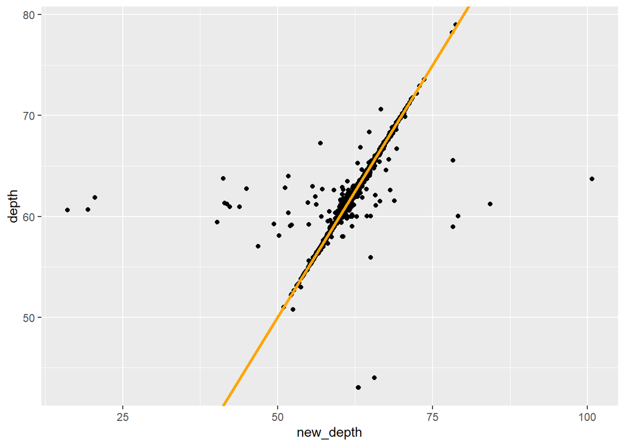

```r
# diamonds[, calculate := 2 * z / (x + y)]
diamonds %>%
  ggplot(., aes(x = new_depth, y = depth)) +
  geom_jitter() +
  geom_abline(intercept = 0, slope = 1, color="orange", size=1.2)
```

From the plot, we can say that most of the depth values are almost equal. But, there are some rows that their `depth` and `new_depth` values are far from each others.

```r
diamonds %>%
  filter(!(abs(new_depth - depth) < 11)) %>%
  select(new_depth, depth, x, y, z)
```

```
## # A tibble: 20 x 5
##    new_depth depth     x     y     z
##        <dbl> <dbl> <dbl> <dbl> <dbl>
##  1      51.2  62.8  6.26  6.19  3.19
##  2      63.1  43    6.32  6.27  3.97
##  3      65.7  44    6.31  6.24  4.12
##  4      51.7  64    7.15  7.04  3.67
##  5      63.0  43    6.53  6.55  4.12
##  6      16.1  60.6  6.62  6.67  1.07
##  7      20.5  61.9  7.43  7.5   1.53
##  8      19.4  60.7  7.31  7.22  1.41
##  9      40.3  59.4  8.49  8.45  3.41
## 10      78.3  59    6.16  6.15  4.82
## 11      41.4  61.3  8.52  8.42  3.51
## 12      78.3  65.6  7.89  7.84  6.16
## 13      79.1  60    6.29  6.25  4.96
## 14      41.8  61.2  8.42  8.37  3.51
## 15      45.0  62.7  8.02  7.95  3.59
## 16      41.2  63.8  8.9   8.85  3.66
## 17      84.3  61.2  4.51  6.02  4.44
## 18      43.9  60.9  4.71  4.68  2.06
## 19      42.3  61    5.31  5.34  2.25
## 20     101.   63.7  5.01  5.04  5.06
```

There are 20 observations. When we compare it with the number of all observations in the dataset, it is very small value. So, we can remove them from the dataset.

```r
diamonds = diamonds %>%
  filter((abs(new_depth - depth) < 11))
diamonds = subset(diamonds, select = -c(new_depth))
```

Now, we can compare the x, y and z values with each other.

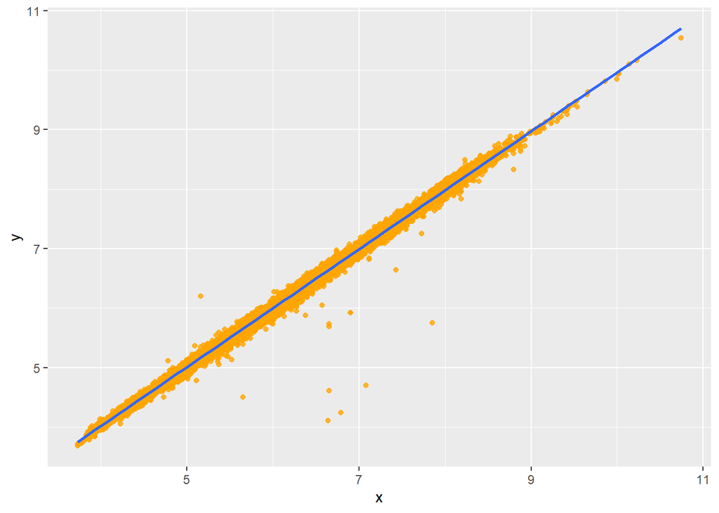

```r
diamonds %>%
  ggplot(., aes(x = x, y = y)) +
  geom_point(color="orange", alpha=0.8) +
  geom_smooth(method = "lm")
```

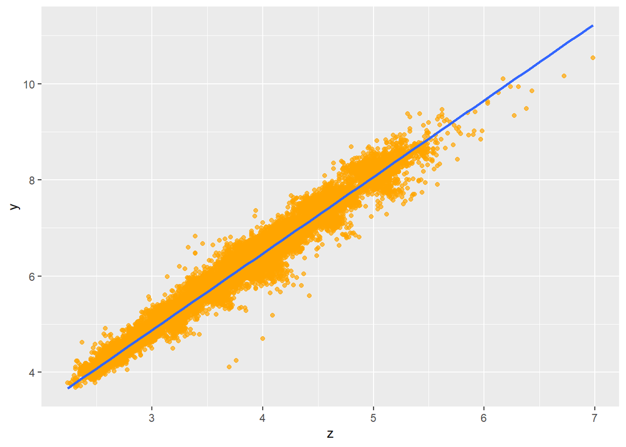

```r
diamonds %>%
  ggplot(., aes(x = z, y = y)) +
  geom_point(color="orange", alpha=0.7) +
  geom_smooth(method = "lm")
```

As expected, these values are highly correlated. We can assume that these x, y and z values are valid values.

# 3 Exploratory Data Analysis

After the pre-processing of the data, we make EDA for the `diamonds` dataset by using variant variables.

## 3.1 Quality of Cut

In this data set, quality of cut is given as categorical variables. Fair is the lowest quality, whereas, ideal is the highest quality. For this reason, to examine diamond dataset by using this feature, first I illustrate the number of trials grouped according to the cut feature.

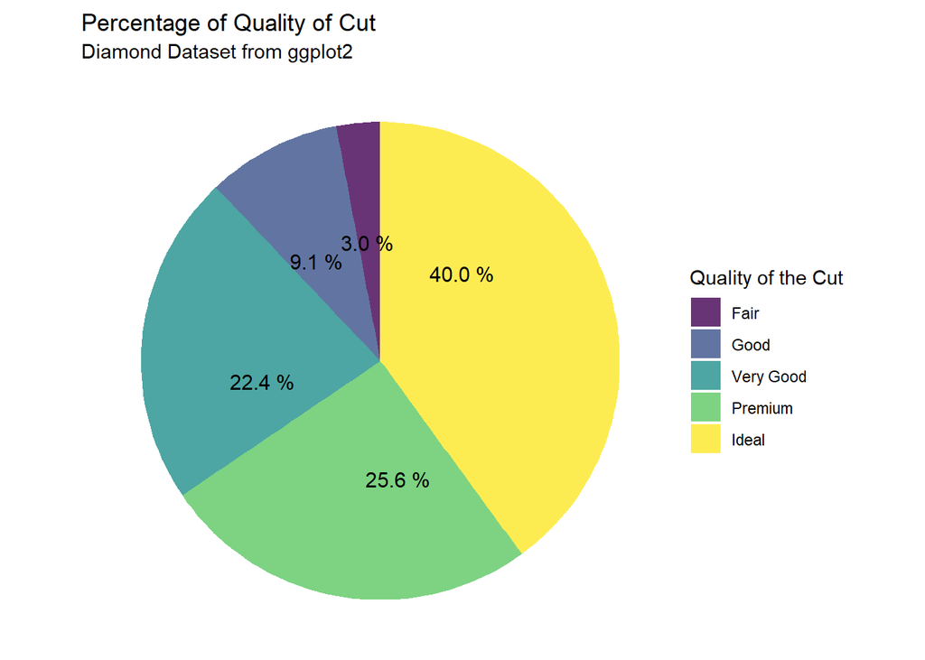

```r
diamonds %>%
  #mutate(cut = factor(cut)) %>%
  group_by(cut) %>%
  summarise(count = n()) %>%
  mutate(percentage = 100*count/sum(count)) %>%

ggplot(., aes(x = '', y = count, fill = cut)) +
  geom_bar(width = 1, stat = "identity", alpha = 0.8) +
  coord_polar("y") +
  theme_void() +
  theme(plot.title = element_text(vjust = 0.5)) +
  geom_text(aes(label = paste(format(percentage,digits=2), "%")), size=4, color = "black", position = position_stack(vjust = 0.3)) +
  labs(title = "Percentage of Quality of Cut ",
       subtitle = st,
       fill = "Quality of the Cut")
```

The pie chart illustrates that, most of the diamonds are cut as ideal form. Moreover, percentage of premium and very good are almost equal. On the other hand, there is a little fair cutting type.

```r
diamonds %>%
  group_by(cut) %>%
  summarise(cut_count = n(),
            MinPrice = min(price),
            AveragePrice = mean(price),
            MaxPrice = max(price)) %>%
  #mutate(percentage = 100*count/sum(count)) %>%
  arrange(desc(cut_count)) %>%
  kable(col.names = c("Cut", "Number of Cut Quality", "Min Price", "Avg Price", "Max Price")) %>%
  kable_minimal(full_width = F)
```

| Cut | Number of Cut Quality | Min Price | Avg Price | Max Price |
| --- | --- | --- | --- | --- |
| Ideal | 21480 | 326 | 3461.698 | 18806 |
| Premium | 13738 | 326 | 4576.581 | 18823 |
| Very Good | 12065 | 336 | 3981.305 | 18818 |
| Good | 4888 | 327 | 3916.279 | 18707 |
| Fair | 1594 | 337 | 4334.275 | 18574 |

While, the pie chart presents the percentage of the dataset according to the cut type, the Above table shows the number of trial with cut type. Furthermore, the minimum, average and maximum prices are addressed in this table. Although the most popular cutting type is Ideal cut, its price is not the highest one. According to the average prices, the most expensive diamonds are belongs to Premium if we just look for the cut variable.

## 3.2 Number of Colors

First, we can group according to the color. After this grouping process we can number of diamonds with this group.

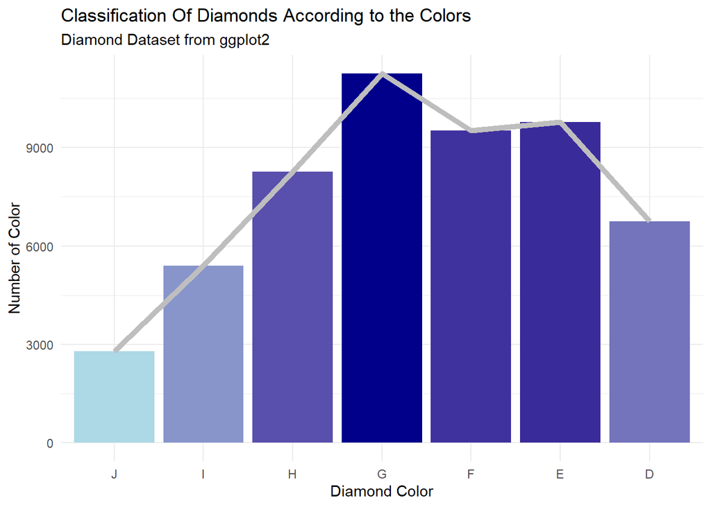

```r
diamonds %>%
  group_by(color)%>%
  summarise(count = n()) %>%

  ggplot(., aes(x=color, y = count, fill = count)) +
  geom_col() +
  scale_fill_gradient("count", low="lightblue", high="darkblue") +
  geom_line(aes(y = count), size = 1.8, color="grey", group = 1) +
  theme_minimal() +
  theme(legend.position = "none") +
  labs(title = "Classification Of Diamonds According to the Colors",
       subtitle = st,
       x = "Diamond Color",
       y = "Number of Color")
```

The bar chart shows that there is at the most G color diamond, whereas, there is at the least J color. We can obtain exact value of each color in data set.

```r
diamonds %>%
  group_by(color)%>%
  summarise(color_count = n(),
            MinPrice = min(price),
            AveragePrice = mean(price),
            MaxPrice = max(price)) %>%
  arrange(color_count) %>%
  kable(col.names = c("Color", "Count","Minimum Price", "Average Price", "Maximum Price")) %>%
  kable_minimal(full_width = F)
```

| Color | Count | Minimum Price | Average Price | Maximum Price |
| --- | --- | --- | --- | --- |
| J | 2800 | 335 | 5327.337 | 18710 |
| I | 5405 | 334 | 5079.123 | 18823 |
| D | 6754 | 357 | 3172.589 | 18693 |
| H | 8263 | 337 | 4474.449 | 18803 |
| F | 9517 | 342 | 3726.559 | 18791 |
| E | 9773 | 326 | 3080.044 | 18731 |
| G | 11253 | 354 | 3997.174 | 18818 |

## 3.3 Clarity

Clarity gives information about diamonds whether it contains stain or not. In this report, to find clarity classification of the data set, i used scatter plot.

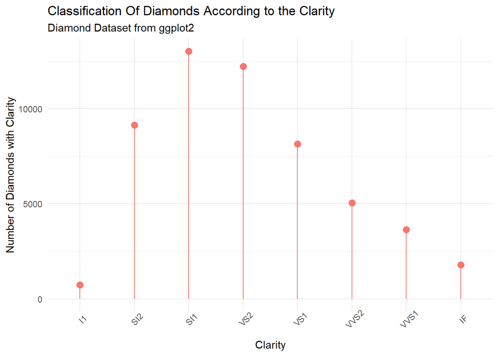

```r
diamonds %>%
  mutate(clarity = factor(clarity)) %>%
  group_by(clarity) %>%
  summarise(clarity_count = n()) %>%

  ggplot(.,aes(x=clarity, y = clarity_count, color= "red2")) +
    geom_point(size=3) +
    geom_segment(aes(x=clarity,
                     xend=clarity,
                     y=0,
                     yend=clarity_count))+
    scale_fill_gradient("clarity_count", low="red", high="red2") +
    theme_minimal() +
    theme(axis.text.x = element_text(angle = 45), legend.position = "none")+
        labs(title = "Classification Of Diamonds According to the Clarity",
         subtitle = st,
         x = "Clarity",
         y = "Number of Diamonds with Clarity")
```

To get more clear analysis, the following table, which shows the number of diamonds according to clarity, can be analyzed.

```r
diamonds %>%
  mutate(clarity = factor(clarity)) %>%
  group_by(clarity) %>%
  summarise(clarity_count = n(),
            MinPrice = min(price),
            AveragePrice = mean(price),
            MaxPrice = max(price)) %>%
  arrange(clarity_count) %>%
  kable(col.names = c("Clarity", "Count","Min Price", "Avg Price", "Max Price")) %>%
  kable_minimal(full_width = F)
```

| Clarity | Count | Min Price | Avg Price | Max Price |
| --- | --- | --- | --- | --- |
| I1 | 739 | 345 | 3924.185 | 18531 |
| IF | 1784 | 369 | 2870.570 | 18806 |
| VVS1 | 3645 | 336 | 2523.088 | 18777 |
| VVS2 | 5055 | 336 | 3286.971 | 18768 |
| VS1 | 8153 | 327 | 3840.792 | 18795 |
| SI2 | 9140 | 326 | 5051.592 | 18804 |
| VS2 | 12223 | 334 | 3925.842 | 18823 |
| SI1 | 13026 | 326 | 3992.932 | 18818 |

According to the average prices, the most expensive diamonds are belongs to SI2 if we just look for the clarity variable. So, it means that we can not explain the response (price) variable only with the clarity type of a diamond.

## 3.4 Carat

In this data table, the carat shows the weight of the carat. To see the most used carat, the number of data is group according to the carat variable.

```r
getmode <- function(v) {
   uniqv <- unique(v)
   uniqv[which.max(tabulate(match(v, uniqv)))]
}
getmode(diamonds$carat)
```

```
## [1] 0.3
```

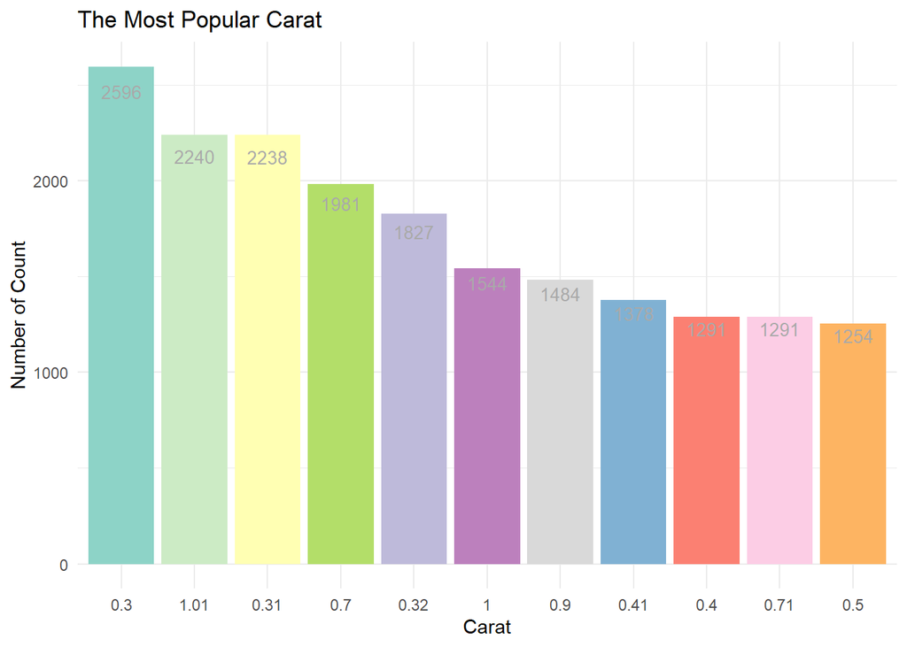

```r
diamonds %>%
  mutate(carat = factor(carat)) %>%
  group_by(carat) %>%
  summarise(carat_count = n())%>%
  arrange(desc(carat_count)) %>%
  head(11) %>%
  ggplot(., aes(y=carat_count, x = reorder(carat, -carat_count), fill = carat)) +
  geom_col() +
  geom_text(aes(label = carat_count), size=3.5, color = "darkgrey", position = position_stack(vjust = 0.95)) +
  theme_minimal() +
  scale_fill_brewer(palette = c("Set3")) +
  theme(legend.position = "none") +
  labs(title = "The Most Popular Carat",
       x = "Carat",
       y = "Number of Count")
```

## 3.5 Price and Cut Analysis by Color

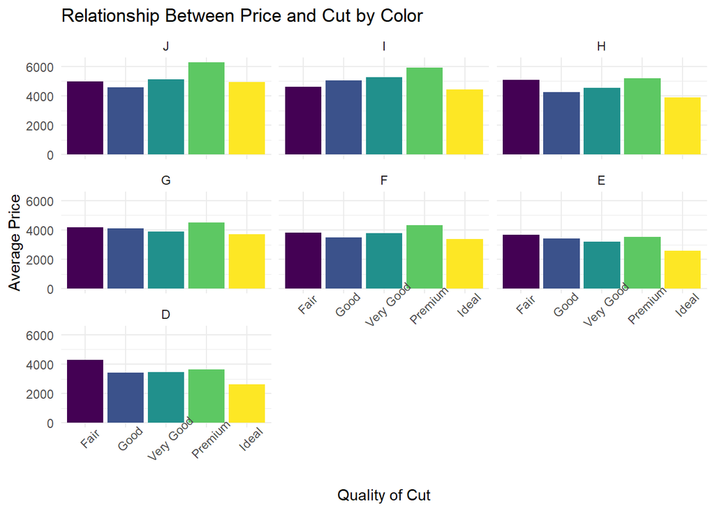

```r
diamonds %>%
  group_by(cut, color) %>%
  summarise(avg_price = mean(price)) %>%

  ggplot(aes(x=cut, y= avg_price, fill = cut)) +
  geom_col() +
  facet_wrap(~color) +
  theme_minimal() +
  theme(axis.text.x = element_text(angle = 45), legend.position = "none") +
  labs(title = "Relationship Between Price and Cut by Color",
       y = "Average Price",
       x = "Quality of Cut")
```

## 3.6 Price and Clarity Analysis by Color

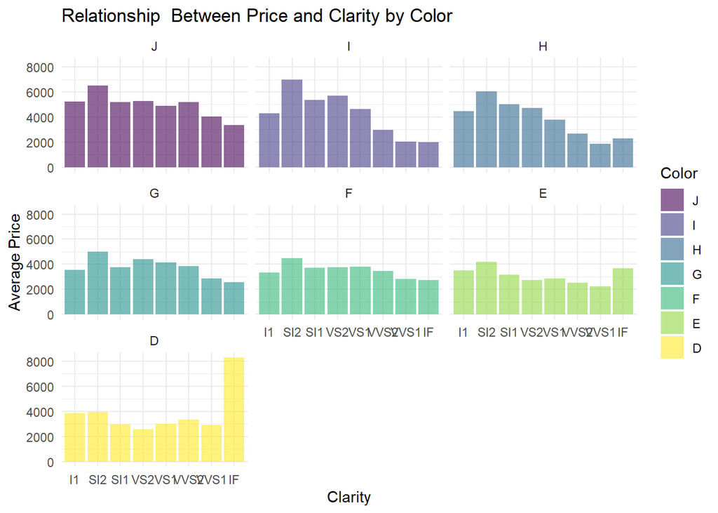

```r
diamonds %>%
  group_by(clarity, color) %>%
  summarise(MeanPrice = mean(price)) %>%
  ggplot(aes(x=clarity, y = MeanPrice, fill = color)) +
  geom_col(alpha = 0.6) +
  theme_minimal() +
  facet_wrap(~color) +
  labs(title = "Relationship  Between Price and Clarity by Color",
       x = "Clarity",
       y = "Average Price",
       fill = "Color")
```

## 3.7 Price and Clarity Analysis by Cut

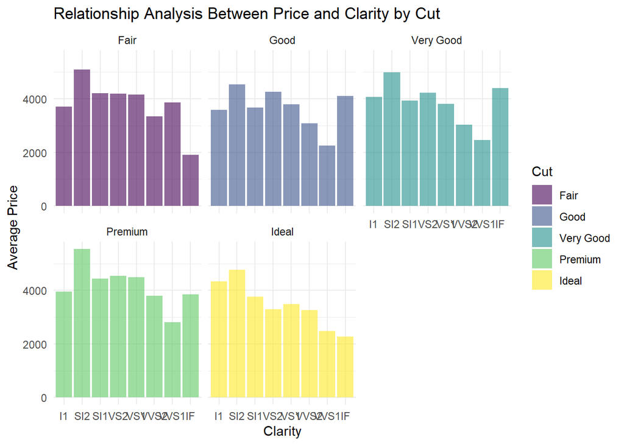

```r
diamonds %>%
  group_by(clarity, cut) %>%
  summarise(MeanPrice = mean(price)) %>%
  ggplot(aes(x=clarity, y = MeanPrice, fill = cut)) +
  geom_col(alpha = 0.6) +
  theme_minimal() +
  facet_wrap(~cut) +
  labs(title = "Relationship Analysis Between Price and Clarity by Cut",
       x = "Clarity",
       y = "Average Price",
       fill = "Cut")
```

We have the same results like the last plot. SI2, which is the second worst type of clarity, has the highest average price in all cut types. So, we can not explain the price variable with these two types.

## 3.8 Price Histogram

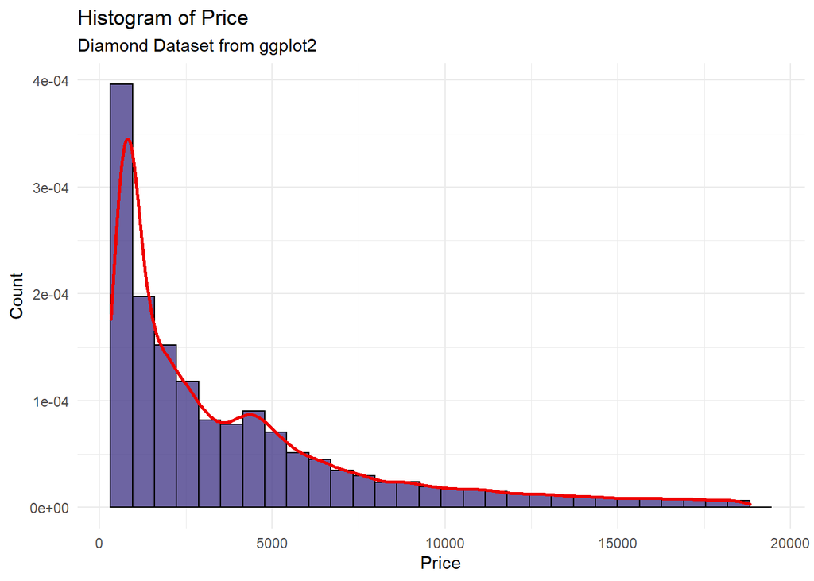

```r
diamonds %>%
  ggplot(aes(x=price)) +
  geom_histogram(aes(y=..density..), position="identity", alpha=0.8, fill = "darkslateblue", color="black") +
  geom_density(alpha=1, size = 1,color="red2")+
  theme_minimal() +
  labs(title = "Histogram of Price",
       subtitle = st,
       x = "Price",
       y = "Count")
```

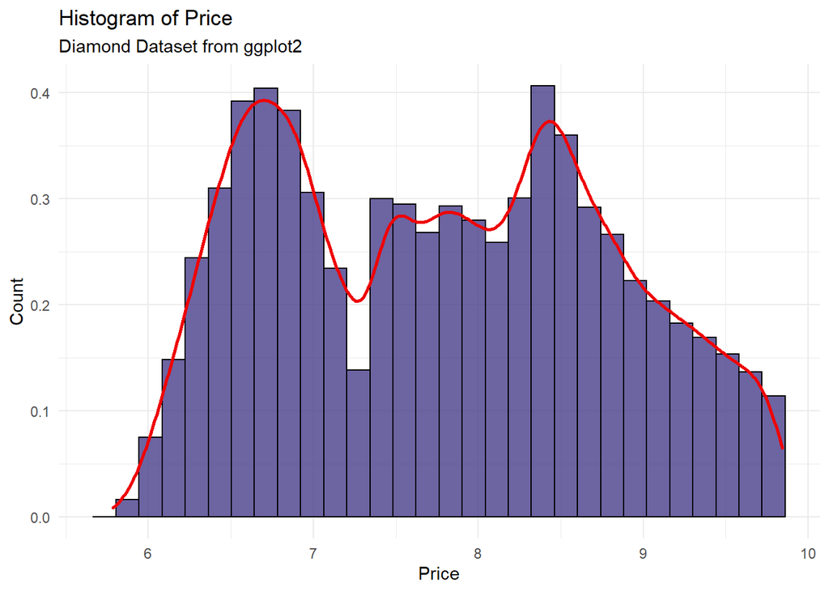

```r
diamonds %>%
  ggplot(aes(x=log(price))) +
  geom_histogram(aes(y=..density..), position="identity", alpha=0.8, fill = "darkslateblue", color="black") +
  geom_density(alpha=1, size = 1,color="red2")+
  theme_minimal() +
  labs(title = "Histogram of Price",
       subtitle = st,
       x = "Price",
       y = "Count")
```

# 4 Feature Extraction / Dimentionality Reduction

At first, we need to divide the data to train and test sets.

```r
set.seed(503)
diamonds_test <- diamonds %>% mutate(diamond_id = row_number()) %>%
    group_by(cut, color, clarity) %>% sample_frac(0.2) %>% ungroup()

diamonds_train <- anti_join(diamonds %>% mutate(diamond_id = row_number()),
    diamonds_test, by = "diamond_id")

diamonds_train = diamonds_train[, c(-ncol(diamonds_train))]
diamonds_test = diamonds_test[, c(-ncol(diamonds_test))]
```

All the ordered columns, we will use them as numeric values.

```r
diamonds_train$cut = as.numeric(diamonds_train$cut)
diamonds_train$clarity = as.numeric(diamonds_train$clarity)
diamonds_train$color = as.numeric(diamonds_train$color)
diamonds_test$cut = as.numeric(diamonds_test$cut)
diamonds_test$clarity = as.numeric(diamonds_test$clarity)
diamonds_test$color = as.numeric(diamonds_test$color)
```

## 4.1 PCA

We can apply PCA to decrease the number of columns in this dataset.

```r
diamonds_pca <- princomp(as.matrix(diamonds_train[,sapply(diamonds_train, class) == "numeric"]),cor=T)
summary(diamonds_pca,loadings=TRUE)
```

```
## Importance of components:
##                           Comp.1    Comp.2    Comp.3    Comp.4     Comp.5
## Standard deviation     2.0743448 1.1892870 1.1060252 0.9927188 0.83129152
## Proportion of Variance 0.4781007 0.1571560 0.1359213 0.1094989 0.07678284
## Cumulative Proportion  0.4781007 0.6352566 0.7711779 0.8806769 0.95745974
##                            Comp.6      Comp.7       Comp.8       Comp.9
## Standard deviation     0.59265505 0.172985644 0.0353090908 2.125041e-02
## Proportion of Variance 0.03902667 0.003324893 0.0001385258 5.017554e-05
## Cumulative Proportion  0.99648641 0.999811299 0.9999498245 1.000000e+00
##
## Loadings:
##         Comp.1 Comp.2 Comp.3 Comp.4 Comp.5 Comp.6 Comp.7 Comp.8 Comp.9
## carat    0.471                       0.126         0.868
## cut     -0.109  0.596  0.451  0.239 -0.175  0.585
## color   -0.158 -0.203         0.802  0.537
## clarity -0.222  0.208  0.212 -0.506  0.778
## depth           0.207 -0.828         0.118  0.492                0.101
## table    0.129 -0.697  0.226 -0.183         0.642
## x        0.475                       0.115        -0.277 -0.722  0.387
## y        0.474                       0.120        -0.299  0.692  0.420
## z        0.474  0.103                0.132        -0.282        -0.815
```

We can see that four components can almost explain 88% of the data. We can choose to use four components for creating a model. Now, we need to add these components to both train and test datasets.

```r
pca_results = predict(diamonds_pca, newdata = diamonds_train)
diamonds_train$pca1 = pca_results[,1]
diamonds_train$pca2 = pca_results[,2]
diamonds_train$pca3 = pca_results[,3]
diamonds_train$pca4 = pca_results[,4]

pca_results_test = predict(diamonds_pca, newdata = diamonds_test)
diamonds_test$pca1 = pca_results_test[,1]
diamonds_test$pca2 = pca_results_test[,2]
diamonds_test$pca3 = pca_results_test[,3]
diamonds_test$pca4 = pca_results_test[,4]
```